# 第一次组会报告

周施远

2023-05-07

# Chapter 1.布拉格傀儡

## 1.1统计”傀儡”

在研究的过程中，我们会借助科学模型来帮助我们进行研究，这些科学模型不能用真假来进行形容，但是它们在帮助我们达成某些研究目的时可以起到很大的作用。 例如我们在统计学研究中就会根据不同的情况来选择不同的统计模型来进行研究，如下图的决策树所示：

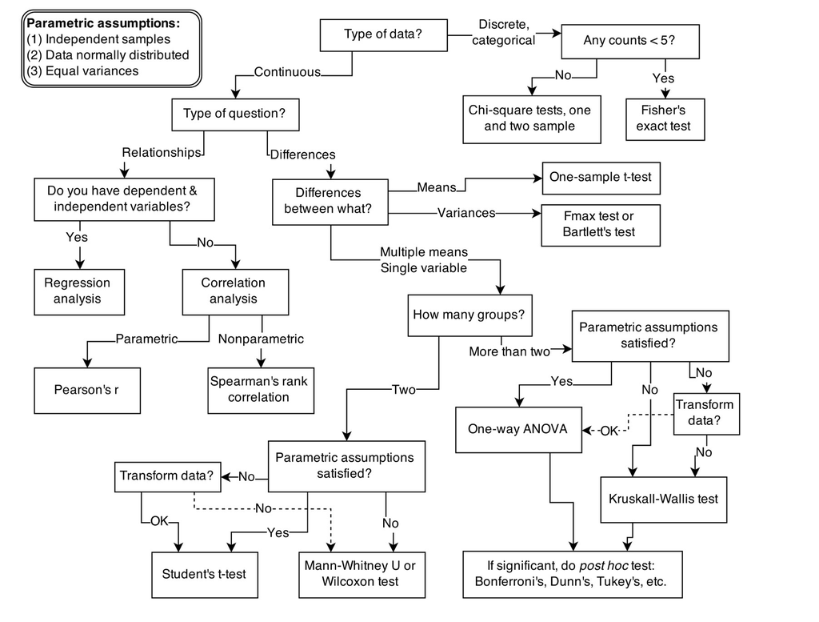

正如上文所说，统计模型可以为我们提供宝贵的信息，但也会导致我们误入歧途。我们需要认识到传统统计工具的使用都是具有很多的前提假设的，但这些前提假设在我们实际使用统计模型的过程中经常会被我们所忽视。因此我们有必要对我们所学过的统计内容进行反思，使得统计工具变成我们应对问题的策略而非简单套用的工具。

## 1.2统计反思

我们需要正确地去认识统计模型与研究假设（区别于假设检验中的H0）之间的关系，与传统认知不同，本书作者认为仅仅利用统计模型的结果就去证伪某一研究假设时不合理的（这一证伪过程需要一整套的科学方法），主要原因有以下几点：

(1)研究假设并非模型。假设与模型之间的关系是错综复杂的而非一一对应的，因此用模型的证伪去得出研究假设的证伪是不合理的。

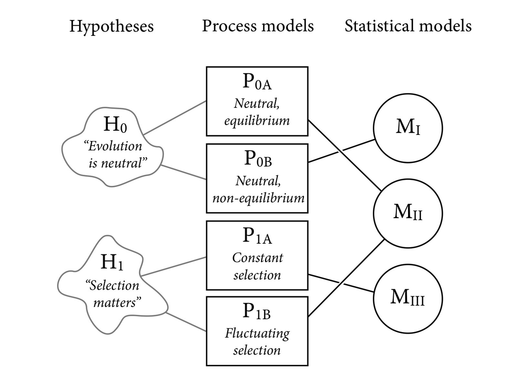

以上图为例，已知H0和H1均正确，如果我们通过统计模型m2去检验研究假设的正确，无论我们是否拒绝m2，我们都会错误地拒绝掉H0或H1中的一个。

(2)测量非常重要，但我们的测量实际上是经常存在问题的。这体现在以下几点：1我们可用反例进行证伪，但不可用它们证实。但问题在于找到一个人们公认的反例大部分情况下很困难。 2测量误差是常态而非个例，我们很难完全避免其对于我们研究的影响。

## 1.3本书重点介绍的一些统计工具

(1)贝叶斯数据分析

贝叶斯学派与传统频率学派数据分析的最大区别在于贝叶斯否认了频率学派认为世界是随机的观点，转而认为随机只是信息的一种特质。而这一观点帮助贝叶斯数据分析在一些问题的解决上获得了独特的优势。

(2)模型比较与预测

在对不同模型进行比较时，优先考虑它们的预测精度是一个较好的选择。而在这其中，作者重点强调了交叉验证（包括保留，k折，留一法等）以及信息准则（AIC等）。

(3)多层次模型

作者认为一些模型中的参数本身就可以引申出一个新的模型，从而形成多层次模型，其最大的优点在于给我们提供了一条解决过拟合的有效路径。它还有以下的优点：

1修正重抽样中重复样本可能会给我们带来的问题

2修正重抽样中抽样不均衡可能会给我们带来的问题

3帮助我们研究总体中不同群体之间的差异

4避免数据标准化后我们对模型的评价虚高的问题

(4)因果模型

大部分的统计模型仅仅对事物之间的相关关系进行了研究，而无法对因果关系进行推断（尽管有时候正确的因果关系并不能帮助我们提升预测精度）。因果模型，例如有向非循环图（DIRECTED ACYCLIC GRAPH, DAG）可以帮助我们去认识事物之间因果关系，但是遗憾的是这一模型需要很多样本数据之外的信息，这也警示我们在进行科学研究时不能迷信数据和统计模型。